# US top 1% and 0.1% wealth shares: conservative estimates

## Introduction

- This page asks how high US top wealth shares are when estimated more conservatively than Saez & Zucman’s equal-return capitalization.
- Outputs: top 0.1% share 1913-2019 (Figure 1); top 1% and 0.1% 1966-2026 in harmonized units plus the Fed DFA (Figure 2); 1989 vs 2016 levels and change (Table 1); three readings of what drove the post-1980 rise.
- Data: the SZZ replication Excel file and the Fed DFA csv, downloaded only if missing from `data/` (setup chunk).

Saez & Zucman’s equal-return capitalization series compared with more conservative estimates:

- Smith, Zidar & Zwick (SZZ, QJE 2023): capitalization with heterogeneous returns
- Survey of Consumer Finances (SCF): Fed household survey, alone and with the Forbes 400 added
- Kopczuk & Saez (2004): estate-tax multiplier estimates
- Fed Distributional Financial Accounts (DFA): SCF shares scaled to national balance sheets

Data sources:

- SZZ: Harvard Dataverse [doi:10.7910/DVN/JKFYMJ](https://doi.org/10.7910/DVN/JKFYMJ)
- DFA: [federalreserve.gov](https://www.federalreserve.gov/releases/z1/dataviz/dfa/)

```r
options(repos = c(CRAN = "https://cran.ism.ac.jp/"))  # Japan mirror (ISM, Tokyo)
pkgs <- c("data.table", "readxl", "qs2", "ggplot2")
new <- pkgs[!vapply(pkgs, requireNamespace, logical(1), quietly = TRUE)]
if (length(new) > 0) install.packages(new)
library(data.table)
library(ggplot2)
dir.create("data", showWarnings = FALSE)

# Download once into data/ (Dataverse file ids from the dataset's file list)
src <- c(SZZ_wealth_excel_exhibits.xlsx = "https://dataverse.harvard.edu/api/access/datafile/6567225",
         `dfa-networth-shares.csv` ="https://www.federalreserve.gov/releases/z1/dataviz/download/dfa-networth-shares.csv")
for (f in names(src)) if (!file.exists(file.path("data", f)))
  download.file(src[f], file.path("data", f), mode = "wb")

# Very faint grey bands for WW1 and WW2, darker grey line at the 1929 crash
wars <- list(annotate("rect", xmin = c(1914, 1939), xmax = c(1918, 1945),
                      ymin = -Inf, ymax = Inf, fill = "grey50", alpha = 0.08),
             geom_vline(xintercept = 1929, colour = "grey60", linewidth = 0.5))
# Okabe-Ito palette: distinguishable under common colour-vision deficiencies
cols <- c("Saez-Zucman (equal returns)" = "#D55E00", "SZZ (heterogeneous returns)" = "#0072B2",
          "SCF" = "#009E73", "SCF + Forbes 400" = "#56B4E9",
          "Estate tax (Kopczuk-Saez)" = "#000000", "DFA (Fed)" = "#CC79A7")
xl <- "data/SZZ_wealth_excel_exhibits.xlsx"
```

```r
# Long run, top 0.1% only (SZZ Fig. I-A): rows 3+ are years, row 2 holds series names
a <- as.data.table(readxl::read_excel(xl, sheet = "DataFig1A", skip = 2, col_names = FALSE))
a <- a[, .(year = as.integer(...1), `SZZ (heterogeneous returns)` = ...2, SCF = ...4,
           `Saez-Zucman (equal returns)` = ...5, `Estate tax (Kopczuk-Saez)` = ...6)]
long <- melt(a, id.vars = "year", variable.name = "series", value.name = "share",
             variable.factor = FALSE)
long <- long[!is.na(share), .(year, series, group = "Top 0.1%", share = as.numeric(share))]

# 1966-2019, top 1% and 0.1%, harmonized units (SZZ Fig. I-B): five series per group
b <- as.data.table(readxl::read_excel(xl, sheet = "DataFig1B", skip = 3, col_names = FALSE))
nm <- c("SZZ (heterogeneous returns)", "PSZ", "SCF", "SCF + Forbes 400", "Saez-Zucman (equal returns)")
grp <- c(`Top 1%` = 17, `Top 0.1%` = 12)          # first column of each group's block
harm <- rbindlist(lapply(names(grp), function(g) {
  x <- b[, c(1, grp[g]:(grp[g] + 4)), with = FALSE]
  setnames(x, c("year", nm))
  x <- melt(x, id.vars = "year", variable.name = "series", value.name = "share",
            variable.factor = FALSE)
  x[, .(year = as.integer(year), series, group = g, share = as.numeric(share))]
}))
harm <- harm[!is.na(share) & series != "PSZ"]

# DFA: households, quarterly from 1989; keep each year's last quarter
dfa <- fread("data/dfa-networth-shares.csv")
dfa[, `:=`(year = as.integer(substr(Date, 1, 4)), q = substr(Date, 7, 7))]
dfa <- dfa[Category %in% c("TopPt1", "RemainingTop1")]
setorder(dfa, year, q)
dfa <- dfa[, .SD[q == max(q)], by = year]
dfa <- dfa[, .(`Top 0.1%` = `Net worth`[Category == "TopPt1"],
               `Top 1%` = sum(`Net worth`)), by = year]
dfa <- melt(dfa, id.vars = "year", variable.name = "group", value.name = "share",
            variable.factor = FALSE)[, series := "DFA (Fed)"]

recent <- rbind(harm, dfa[, .(year, series, group, share)])
qs2::qs_save(list(long = long, recent = recent), "data/us_top_wealth_conservative.qs2")
recent[, .(obs = .N, from = min(year), to = max(year)), by = .(group, series)]
```

```
       group                      series   obs  from    to
      <char>                      <char> <int> <int> <int>
 1:   Top 1% SZZ (heterogeneous returns)    51  1966  2016
 2:   Top 1%                         SCF    11  1989  2019
 3:   Top 1%            SCF + Forbes 400    11  1989  2019
 4:   Top 1% Saez-Zucman (equal returns)    54  1966  2019
 5: Top 0.1% SZZ (heterogeneous returns)    51  1966  2016
 6: Top 0.1%                         SCF    11  1989  2019
 7: Top 0.1%            SCF + Forbes 400    11  1989  2019
 8: Top 0.1% Saez-Zucman (equal returns)    54  1966  2019
 9: Top 0.1%                   DFA (Fed)    38  1989  2026
10:   Top 1%                   DFA (Fed)    38  1989  2026
```

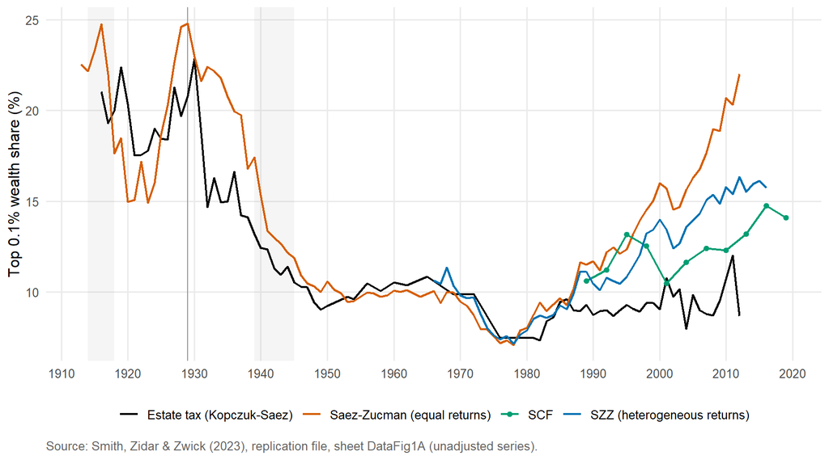

Figure 1: Top 0.1% wealth share (%), 1913-2019: equal-return capitalization (Saez-Zucman 2016) vs. more conservative estimates.

```r
ggplot(long, aes(year, share, colour = series)) +
  wars +
  geom_line(linewidth = 0.8) +
  geom_point(data = long[series == "SCF"], size = 1.6) +
  scale_colour_manual(values = cols, name = NULL) +
  scale_x_continuous(breaks = seq(1910, 2020, 10)) +
  labs(x = NULL, y = "Top 0.1% wealth share (%)",
       caption = "Source: Smith, Zidar & Zwick (2023), replication file, sheet DataFig1A (unadjusted series).") +
  theme_minimal(base_size = 12) +
  theme(legend.position = "bottom", panel.grid.minor = element_blank(),
        plot.caption = element_text(hjust = 0, colour = "grey40"))
```